# Reproducible Research Assignment 1

Amanda Carnicello

Thursday, March 12, 2015

The goal of this assignment is to make an HTML document summarizing the data which consists of number of steps from an anonymous individual over 2 months. The steps are separated into 5 minute intervals over each day of the two months.

### Set UP R

1. The following loads necessary R packages for the whole analysis and numbers are set not to be shown in scientific notation and rounded to 3 significant digits.

```r
    library("dplyr", lib.loc="~/R/win-library/3.1")
    library("lubridate", lib.loc="~/R/win-library/3.1")
    library("ggplot2", lib.loc="~/R/win-library/3.1")

    options(scipen = 1, digits = 3)
```

### Load Data

1. The following code loads the data into R for analysis.

```r
    act <- read.csv("activity.csv")
    head(act)
```

```
##   steps       date interval
## 1    NA 2012-10-01        0
## 2    NA 2012-10-01        5
## 3    NA 2012-10-01       10
## 4    NA 2012-10-01       15
## 5    NA 2012-10-01       20
## 6    NA 2012-10-01       25
```

2. Change date column from factors to dates.

```r
    act <- act %>% mutate(date =  ymd(date))
```

### What is mean total number of steps taken per day?

1. Calculate the total number of steps taken per day.

```r
    totalday <- act %>% group_by(date) %>% summarize(DayTotal=sum(steps, na.rm=TRUE))
    totalday
```

```
## Source: local data frame [61 x 2]
##
##          date DayTotal
## 1  2012-10-01        0
## 2  2012-10-02      126
## 3  2012-10-03    11352
## 4  2012-10-04    12116
## 5  2012-10-05    13294
## 6  2012-10-06    15420
## 7  2012-10-07    11015
## 8  2012-10-08        0
## 9  2012-10-09    12811
## 10 2012-10-10     9900
## ..        ...      ...
```

2. Make a histogram of the total number of steps taken each day.

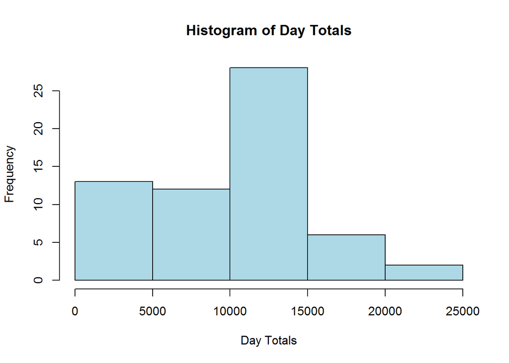

```r
    hist(totalday$DayTotal, main = "Histogram of Day Totals", xlab = "Day Totals", col = "light blue")
```

3. Calculate and report the mean and median of the total number of steps taken per day.

```r
    TotalDayMean <- mean(totalday$DayTotal)
    TotalDayMedian <- median(totalday$DayTotal)
```

The mean of the total steps taken per day was 9354.23. The median of the total steps taken per day was 10395.

### What is the average daily activity pattern?

1. Make a time series plot (i.e. type = “l”) of the 5-minute interval (x-axis) and the average number of steps taken, averaged across all days (y-axis)

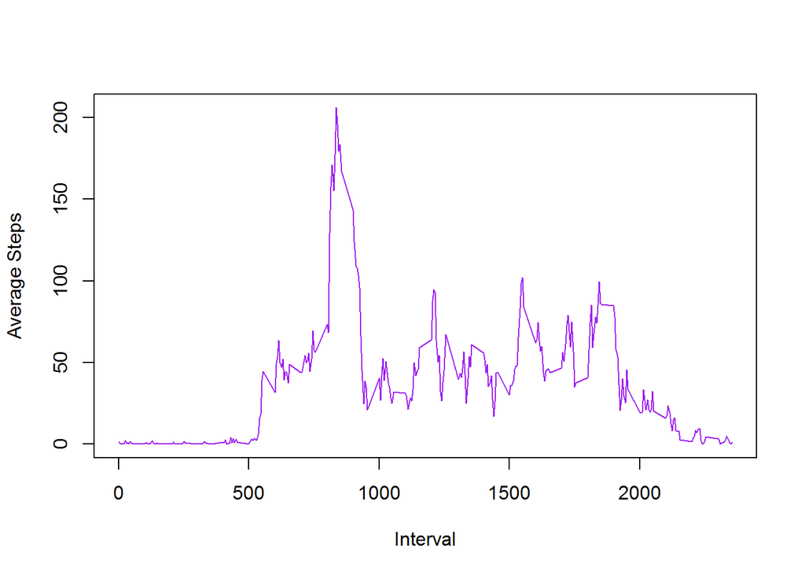

```r
    AveInterval <- act %>% group_by(interval) %>% summarize(IntervalAve=mean(steps, na.rm=TRUE))

    plot(AveInterval$interval,AveInterval$IntervalAve, type="l",xlab="Interval",ylab="Average Steps",col="purple")
```

```r
MaxAveSteps = max(AveInterval$IntervalAve)
MaxInterval = AveInterval$interval[which(AveInterval$IntervalAve==MaxAveSteps)]
```

### Imputing missing values

Note that there are a number of days/intervals where there are missing values (coded as NA). The presence of missing days may introduce bias into some calculations or summaries of the data.

1. Calculate and report the total number of missing values in the dataset (i.e. the total number of rows with NAs)

```r
    NACount <- sum(is.na(act$steps))
```

There are 2304 NAs in the dataset.

2. Devise a strategy for filling in all of the missing values in the dataset. The strategy does not need to be sophisticated. For example, you could use the mean/median for that day, or the mean for that 5-minute interval, etc.

The mean of the interval will be used to fill in any NAs occurring in the dataset.

3. Create a new dataset that is equal to the original dataset but with the missing data filled in.

```r
    #copy raw dataset to new varible
    FixAct <- act
    #replace each na with mean steps of interval over all days.
    FixAct[which(is.na(FixAct$steps)),1] <- AveInterval[match(FixAct[which(is.na(FixAct$steps)),3],AveInterval$interval),2]

    #show first 6 rows of FixAct to show change
    head(FixAct)
```

```
##    steps       date interval
## 1 1.7170 2012-10-01        0
## 2 0.3396 2012-10-01        5
## 3 0.1321 2012-10-01       10
## 4 0.1509 2012-10-01       15
## 5 0.0755 2012-10-01       20
## 6 2.0943 2012-10-01       25
```

4. Make a histogram of the total number of steps taken each day and Calculate and report the mean and median total number of steps taken per day. Do these values differ from the estimates from the first part of the assignment? What is the impact of imputing missing data on the estimates of the total daily number of steps?

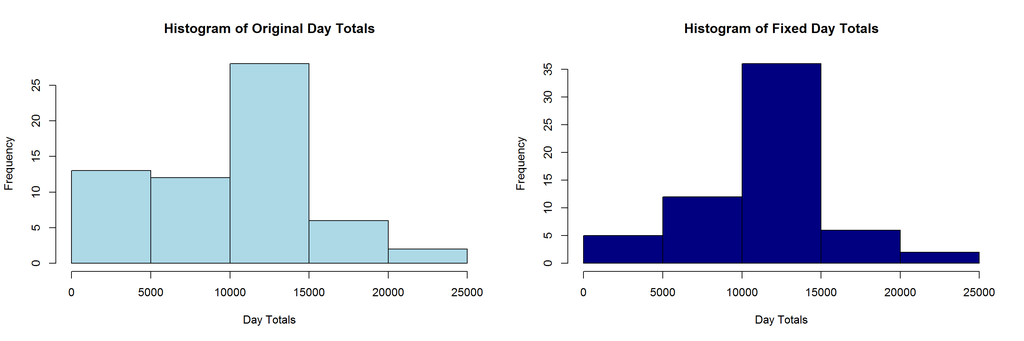

```r
    #Create total steps per day summary
    FixTotalDay <- FixAct %>% group_by(date) %>% summarize(DayTotal=sum(steps, na.rm=TRUE))

    #fix graph parameters
    par(mfrow=c(1,2))

    #recreate original graph
    with(totalday,

    hist(DayTotal, main = "Histogram of Original Day Totals", xlab = "Day Totals", col = "light blue")

    )

    #show histogram with fixed data.
    with(FixTotalDay,

    hist(DayTotal, main = "Histogram of Fixed Day Totals", xlab = "Day Totals", col = "navy")

    )
```

```r
    #calulate mean and meadian of fixed data
    FixTotalDayMean <- mean(FixTotalDay$DayTotal)
    FixTotalDayMedian <- median(FixTotalDay$DayTotal)
```

The new mean of the total steps taken per day is 10766.189 vs the old mean of 9354.23. The new median of the total steps taken per day is 10766.189 vs the old median of 10395. The mean and the median both increased when the NAs were replaced. Also the histogram became more symetrical.

### Are there differences in activity patterns between weekdays and weekends?

1. Create a new factor variable in the dataset with two levels - “weekday” and “weekend” indicating whether a given date is a weekday or weekend day.

```r
    #add new row to show weekend or weekdays
    FixAct <- FixAct %>% mutate(weekend=factor(1*(weekdays(date)=="Saturday"|weekdays(date)=="Sunday"),labels=c("weekday","weekend")))

    #show part of fixed data with a weekday and a weekend day to show column was added correctly.
    head(FixAct[1435:1445,],10)
```

```
##      steps       date interval weekend
## 1435     0 2012-10-05     2330 weekday
## 1436     0 2012-10-05     2335 weekday
## 1437     0 2012-10-05     2340 weekday
## 1438     0 2012-10-05     2345 weekday
## 1439     0 2012-10-05     2350 weekday
## 1440     0 2012-10-05     2355 weekday
## 1441     0 2012-10-06        0 weekend
## 1442     0 2012-10-06        5 weekend
## 1443     0 2012-10-06       10 weekend
## 1444     0 2012-10-06       15 weekend
```

2. Make a panel plot containing a time series plot (i.e. type = “l”) of the 5-minute interval (x-axis) and the average number of steps taken, averaged across all weekday days or weekend days (y-axis). See the README file in the GitHub repository to see an example of what this plot should look like using simulated data.

```r
    #summarize FixAct to get Ave steps over each interval seperated by weekend vs weekdays
    WeekAveInterval <- FixAct %>% group_by(weekend,interval) %>% summarize(IntervalAve=mean(steps, na.rm=TRUE))

    WeekAveInterval
```

```
## Source: local data frame [576 x 3]
## Groups: weekend
##
##    weekend interval IntervalAve
## 1  weekday        0       2.251
## 2  weekday        5       0.445
## 3  weekday       10       0.173
## 4  weekday       15       0.198
## 5  weekday       20       0.099
## 6  weekday       25       1.590
## 7  weekday       30       0.693
## 8  weekday       35       1.138
## 9  weekday       40       0.000
## 10 weekday       45       1.796
## ..     ...      ...         ...
```

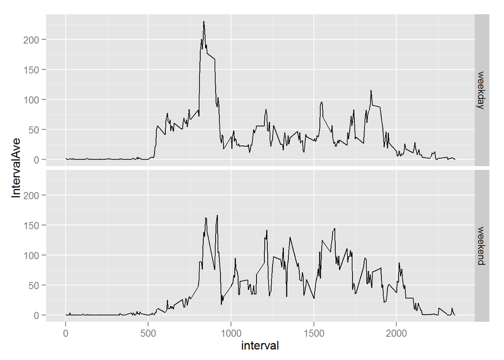

```r
    #Plot invervals versus interval averages seperated by weekend vs weekdays
    qplot(interval, IntervalAve, data = WeekAveInterval,geom = "line", facets = weekend ~ .)
```